# **What Is The State of Food Security and Nutrition in the US?**

# 6 **State of Food Security in the United States**

Figure 1 below shows that while food insecurity among households has been falling from 2010, there is a steep rise in food insecurity from 2020. The rise is evident among the households with `very low` food insecurity and the households with both `low` and `very low` food security. Importantly, the households with very low food security have consistently been above 3% and above 10% for households with low and very low food security. This observation means that there no measures in place to address food insecurity among the poor. Alternatively, measures in place to address food insecurity are either badly executed or ineffective in addressing the persistent food insecurity. Food insecurity among the very vulnerable has hit a high of 5% that was prevalent in between 2007 and 2015. This rise in food insecurity is a cause for concern. It is important to establish the factors that lead to the uptick in the cases of food insecurity from around 2020. If not addressed, this rise is likely to take the United States back to the years of high food insecurity of the 2010’s. COVID 19 economic slowdown could explain some of the observed rise in food insecurity. Steps to mitigate this reversal is critical.

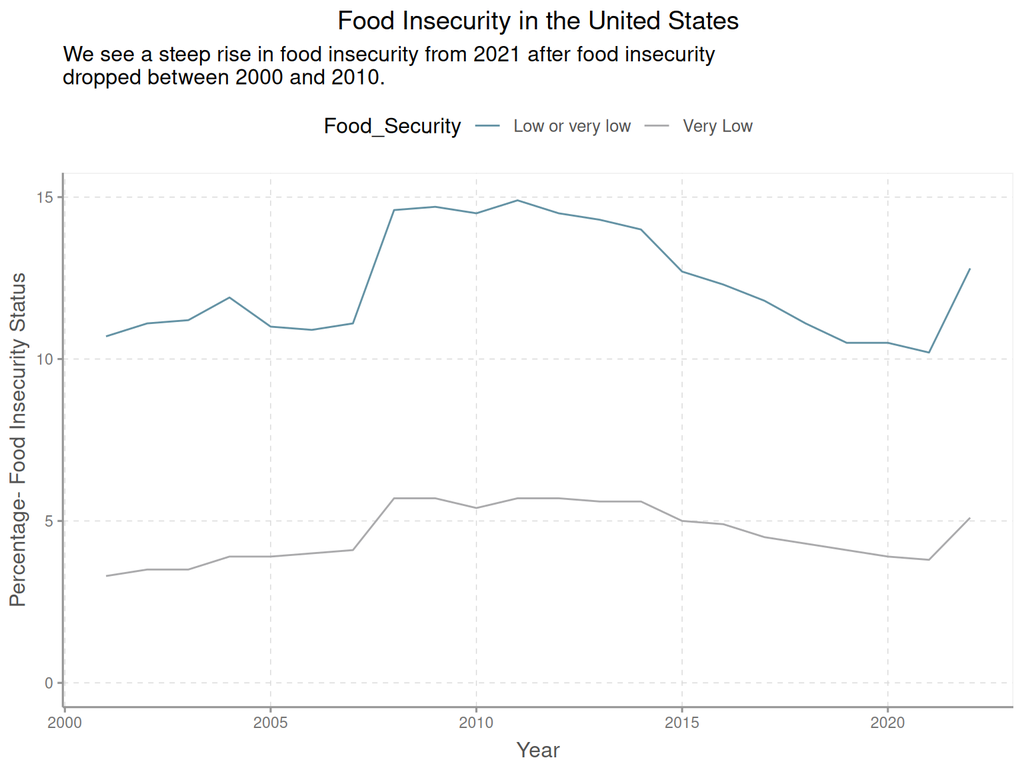

Trends in Food Insecurity in the US

```r
trends %>%
  mutate(state = case_when(
    state == "Food_security_low_and_very_low" ~ "Low or very low",
    .default = "Very Low"
  )) %>%
  rename(Food_Security = state) %>%
  ggplot(mapping = aes(x = year, y = value, color = Food_Security)) +
  geom_line() +
  ylim(0, 15) +
  labs(x = "Year", y = "Percentage- Food Insecurity Status",
       title = "Food Insecurity in the United States",
       subtitle = "We see a steep rise in food insecurity from 2021 after food insecurity \ndropped between 2000 and 2010.") +
  scale_color_manual(values = pal("economist")) +
  theme(legend.position = "top")
```

A substantial number of people in the United States are food insecure. Figure 2 below shows that about 17% of households fall under this category. We also see that over 8% of adults with children are food insecure. This means that these adults are sacrificing their calorie intake to feed the children. Moreover, 7.8% of children in the United States live in households that have low food security putting their health at risk. What is more, 1% of children live in homes with very low food security. These two latter categories put the children at a high risk of malnutrition, which could further affect their future potential. Thus, more resources should be set aside to support poor households, especially households with children.

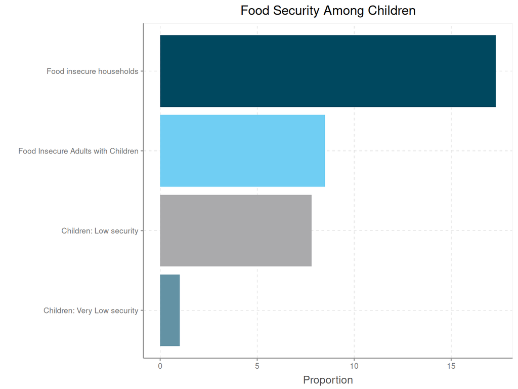

Food Insecurity among Children in the US

```r
food_security %>%
  mutate(food_security_status = case_when(
    food_security_status == "Food insecurity among adults only in households with children" ~ "Food Insecure Adults with Children",
    food_security_status == "Low food security among children" ~ "Children: Low security",
    food_security_status == "Very low food security among children" ~ "Children: Very Low security",
    .default = food_security_status
  )) %>%
  mutate(prop = case_when(
    food_security_status == "Food-secure households" ~ 100-82.7,
    .default = prop
  )) %>%
  mutate(food_security_status = case_when(
    food_security_status == "Food-secure households" ~ "Food insecure households",
    .default = food_security_status
  )) %>%
  mutate(
    food_security_status = fct_reorder(food_security_status, prop)
  ) %>%
  ggplot(mapping = aes(x = food_security_status, y = prop,
                       fill = food_security_status)) +
  geom_col(show.legend = FALSE) +
  labs(
    x = "",
    y = "Proportion",
    title = "Food Security Among Children"
  ) +
  coord_flip() +
  scale_fill_manual(values = pal("economist"))
```

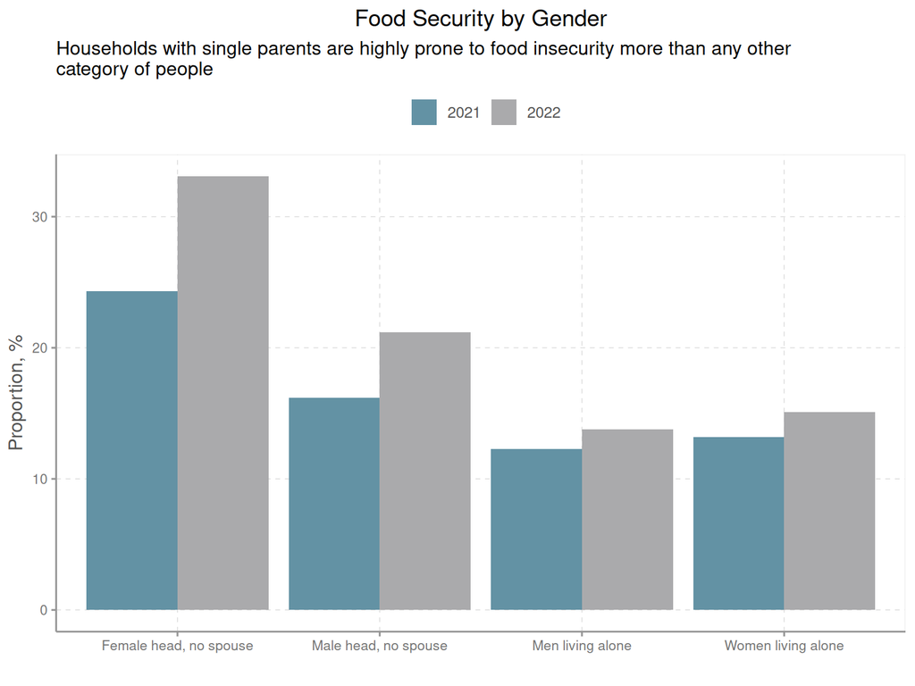

Food Insecurity by Gender in the US

```r
insecure %>%
  dplyr::filter(subclass %in% c("Female head, no spouse",
                         "Male head, no spouse",
                         "Women living alone",
                         "Men living alone")) %>%
  dplyr::select(-class, -sig, -perc) %>%
  pivot_longer(-subclass,
               names_to = "Year") %>%
  mutate(Year = str_remove(Year, "^perc_"),
         Year = as.numeric(Year)) %>%
  ggplot(mapping = aes(x = subclass,
                       y = value,
                       fill = factor(Year))) +
  geom_col(position = "dodge") +
  theme(legend.position = "top",
        legend.title = element_blank()) +
  scale_fill_manual(values = pal("economist")) +
  labs(x = "", y = "Proportion, %",
       title = "Food Security by Gender",
       subtitle = "Households with single parents are highly prone to food insecurity more than any other\ncategory of people")
```

## 6.2 **Poverty, food insecurity, malnutrition and starvation**

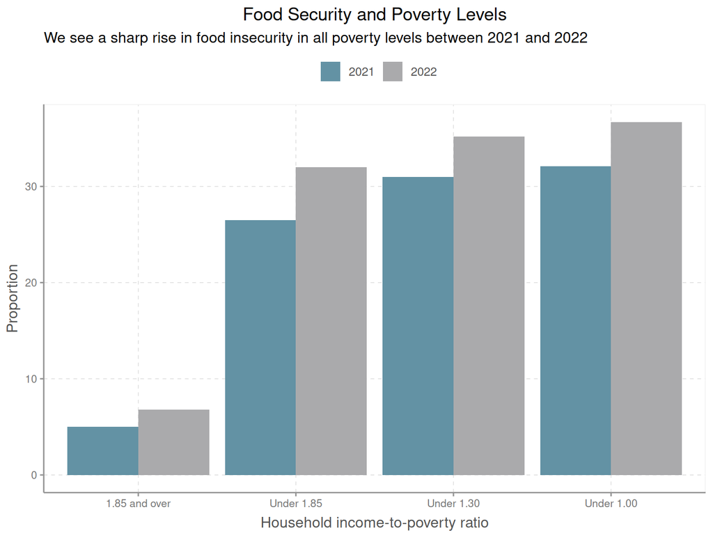

Food Insecurity and Poverty in the US

```r
insecure %>%
  dplyr::filter(class == "Household income-to-poverty ratio:") %>%
  dplyr::select(-perc, -sig) %>%
  pivot_longer(-c(class, subclass),
               names_to = "Year") %>%
  mutate(Year = str_remove(Year, "^perc\\_"),
         Year = as.numeric(Year)) %>%
  mutate(subclass = fct_reorder(subclass, value)) %>%
  ggplot(aes(x = subclass, y = value, fill = factor(Year))) +
  geom_col(position = "dodge") +
  scale_fill_manual(values = pal("economist")) +
  theme(legend.position = "top") +
  labs(x = "Household income-to-poverty ratio",
       y = "Proportion",
       title = "Food Security and Poverty Levels",
       subtitle = "We see a sharp rise in food insecurity in all poverty levels between 2021 and 2022") +
  theme(legend.title = element_blank())
```

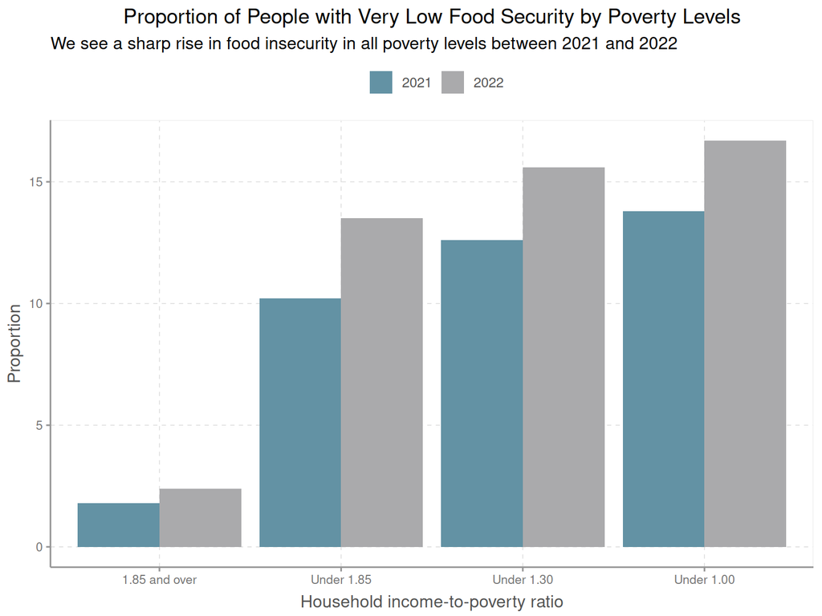

Propoprtion of People with Very Low Food Security by Poverty Levels

```r
very_low %>%
  dplyr::filter(class == "Household income-to-poverty ratio:") %>%
  dplyr::select(-perc, -sig) %>%
  pivot_longer(-c(class, subclass),
               names_to = "Year") %>%
  mutate(Year = str_remove(Year, "^perc\\_"),
         Year = as.numeric(Year)) %>%
  mutate(subclass = fct_reorder(subclass, value)) %>%
  ggplot(aes(x = subclass, y = value, fill = factor(Year))) +
  geom_col(position = "dodge") +
  scale_fill_manual(values = pal("economist")) +
  theme(legend.position = "top") +
  labs(x = "Household income-to-poverty ratio",
       y = "Proportion",
       title = "Proportion of People with Very Low Food Security by Poverty Levels",
       subtitle = "We see a sharp rise in food insecurity in all poverty levels between 2021 and 2022") +
  theme(legend.title = element_blank())
```